# NEST Simulations: Integrate-and-Fire Neuron

This notebook follows Section 2 *First Steps* of *NEST by Example: An Introduction to the Neural Simulation Tool NEST Version 2.6.0* by Gewaltig, et al [1].

## Configurations

**Events**  
The neuron responds to an alternating current with `frequency = 2.0 Hz`, `amplitude = 100.0 mV`.  
Aside from this, the neuron also receives spike events from connected nodes.

**Connected Nodes**  
It is connected to two large populations of excitatory and inhibitory neurons.

> *Excitatory neurons*  
> `average firing rate = 1 Hz`  
> `population size = 70000`  
> `delay = 1 ms`

> *Inhibitory neurons*  
> `average firing rate = 1 Hz`  
> `population size = 20000`  
> `delay = 1 ms`

**Recording**  
The voltmeter records the simulation for `time = 1000 ms`.

## Simulations

### 1. Initial Configuration

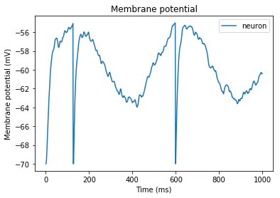

```python
import nest
import nest.voltage_trace
import matplotlib.pyplot as plt

# Initialize neuronal elements
neuron = nest.Create('iaf_psc_alpha')
sine = nest.Create('ac_generator', 1,
                    {'amplitude': 100.0,
                    'frequency': 2.0})
noise = nest.Create('poisson_generator', 2,
                    [{'rate': 70000.0},
                     {'rate': 20000.0}])
voltmeter = nest.Create('voltmeter', 1,
                       {'withgid': True})

# Start simulation
def run():
    nest.Connect(sine, neuron)
    nest.Connect(voltmeter, neuron)
    nest.Connect(noise[:1], neuron, syn_spec={'weight': 1.0, 'delay': 1.0})
    nest.Connect(noise[1:], neuron, syn_spec={'weight': -1.0, 'delay': 1.0})
    nest.Simulate(1000.0)
    p = nest.voltage_trace.from_device(voltmeter)

    # Plot settings
    l = plt.legend()
    l.get_texts()[0].set_text('neuron')
    plt.show()

run()
```

The plot shows two spiking events occuring at `~110 ms` and `600 ms`.  
These happened when the membrane potential reached the firing threshold at `-55 mV`.  
At these points, the membrane potential is reset to `-70 mV`.

### 2. Increasing Excitatory Nodes

Now we try increasing the number of excitatory neurons.

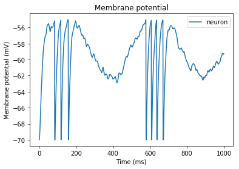

```python
# Start with clean network
nest.ResetKernel()

# Change configurations
neuron = nest.Create('iaf_psc_alpha')
sine = nest.Create('ac_generator', 1,
                    {'amplitude': 100.0,
                    'frequency': 2.0})
noise = nest.Create('poisson_generator', 2,
                    [{'rate': 75000.0},         # increase population from 70000 to 75000
                     {'rate': 20000.0}])
voltmeter = nest.Create('voltmeter', 1,
                       {'withgid': True})

run()
```

From the plot we can see that **increasing the excitatory neuron population** affects the **number of spike events** occuring in the neuron.

### 3. Increasing Inhibitory Nodes

Next we try increasing the number of inhibitory neurons.

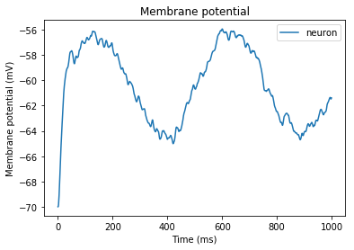

```python
# Start with clean network
nest.ResetKernel()

# Change configurations
neuron = nest.Create('iaf_psc_alpha')
sine = nest.Create('ac_generator', 1,
                    {'amplitude': 100.0,
                    'frequency': 2.0})
noise = nest.Create('poisson_generator', 2,
                    [{'rate': 70000.0},
                     {'rate': 25000.0}])         # increase population from 20000 to 25000
voltmeter = nest.Create('voltmeter', 1,
                       {'withgid': True})

run()
```

From the plot, we can see that the **increase in inhibitory neuron population prevents the spiking event** from happening.

## References

[1] Gewaltig, M., Morrison, A., & Plesser, H. (2014). NEST by Example: An Introduction to the Neural Simulation Tool NEST Version 2.6.0. Retrieved October 6, 2017, from http://www.nest-simulator.org/wp-content/uploads/2015/02/NEST_by_Example.pdf

`Document Created: 6 October 2017`  
`Author: Paul Rossener Regonia`